# 第三次量子计算作业

- Info ：

韩懿杰 20213006413

## 1.理论说明

### 1.1 Foundation

- 我们选用制备的 $|0\rangle\quad|1\rangle\quad|+\rangle\quad|-\rangle$,一般用光子偏振片，但这不重要。
- 发射者Alice生成一堆01随机数，然后随机使用一种偏振片发出去（或者说是随机选择一组基矢）。
- 接受信息者也不知道到底对面用的什么偏振片，只能胡乱用偏振片接受（理论可用一种，但这种情况就和密码写00000000一样）。
- 然后他们公开所用偏振片（当然编码不公开）。记录偏振方向一样的偏振片对应编码为有效信息，显然大约有50%有效信息。。

### 1.2 被监听情况

- 假如出现Eve去拿偏振片在中间监听。它可以得到上一个情况（无监听）中Bob得到的所有信息，但是它会对信息造成坍缩破坏。
- 坍缩效果如下：
1. 如果Eve猜对了偏振方向，那没什么影响。
2. 如果Eve没有猜对，那会让量子态坍缩到这个偏振方向
- 然后Bob收到偏振片，公开相同偏振片的量子态（大概N/2）个。
- 理论上Bob这些相同偏振片的01编码是和Alice相同的。他们会公开一段编码对照一下。
- 但是如果被Eve监听过了，有约1/2的编码会被Eve猜对偏振方向不变，约1/2会坍缩到另一个量子态。这样Bob检验这些坍缩后的编码只有1/2的概率和Alice的相同。合计有约1/4的编码错误。

## 2.模拟

理论上这样说一下就算证明了，但有点像抄书。于是乎做一个模拟。

### 2.2代码如下：

为节约算力，调整了第4步的顺序，即一开始只关心可用编码位置。

这样的话被Eve错误监听的编码在Bob这里也是随机的，也即我们无需关心Eve具体得到了什么。只模拟他错误偏振片的位置即可。

- 单次计算

```python
import numpy as np
import matplotlib.pyplot as plt
from scipy import stats
import random

def question():
    # Data difinition
    low=0
    high=1
    allnum=1000
    Alice_code=stats.randint.rvs(low, high+1, size=allnum)
    Alice_vector=stats.randint.rvs(low, high+1, size=allnum)
    Bob_vector=stats.randint.rvs(low, high+1, size=allnum)
    Eve_vector=stats.randint.rvs(low, high+1, size=allnum)

    # process
    ## usable info
    usable_se=(Alice_vector==Bob_vector)
    Alice_uscode=Alice_code[usable_se]
    Alice_usvec=Alice_vector[usable_se]
    Bob_usvec=Bob_vector[usable_se]
    Eve_usvec=Eve_vector[usable_se]

    ## Eve monitor and revise vector
    Eve_uscode=Alice_uscode.copy()
    error_se=(Alice_usvec!=Eve_usvec)
    n=np.sum(error_se)

    ## Bob
    Bob_uscode=Alice_uscode.copy()
    Bob_uscode[error_se]=stats.randint.rvs(low, high+1, size=n)

    ## statc
    ### random extract 50% data
    raten=int(0.5*n)
    array=np.arange(0,n)
    random_se = random.sample(list(array), raten)
    Bob_rate=(Bob_uscode[random_se]).copy()
    Alice_rate=(Alice_uscode[random_se]).copy()
    ### Canculate
    numerror=np.sum(Bob_rate!=Alice_rate)
    rate=numerror/raten
    return rate,numerror
info=question()
print("此次错误率：{}".format(info[0]))
```

```
此次错误率：0.24793388429752067
```

- 多次计算

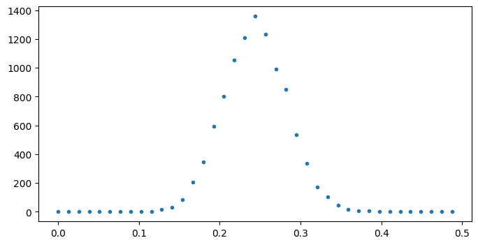

```python
douc=np.array([])
for i in range(10000): #1000个数据点
    info=question()
    random_numbers = info[0]
    douc=np.append(douc,random_numbers)

# 定义区间
bins = np.linspace(0,0.5,40)
# 计算直方图
hist, bin_edges = np.histogram(douc, bins=bins)
# graph
fig= plt.figure(figsize=(8,4))
ax= fig.add_subplot(1,1,1)
ax.plot(bin_edges[0:-1],hist,linestyle='',marker='.')
plt.show()
```

## 3 result

显然结果为错误率均值为0.25，多次重复结果符合高斯分布。